# R Exercises - Basic stuff

2020-10-05

# 1 Exercise 1

- Print the 6 first lines of the R-built-in data.frame `trees`

```r
head(trees,6)
```

```
##   Girth Height Volume
## 1   8.3     70   10.3
## 2   8.6     65   10.3
## 3   8.8     63   10.2
## 4  10.5     72   16.4
## 5  10.7     81   18.8
## 6  10.8     83   19.7
```

- Print only the column names

```r
names(trees)
```

```
## [1] "Girth"  "Height" "Volume"
```

- What is the dimension of `trees`?

```r
dim(trees)
```

```
## [1] 31  3
```

- Plot the trees height and volume as a function of their girth in two different graphs. Make sure the axis labels are clear
- In each graph, add a red dashed line corresponding to the relevant correlation that you observe (average value, linear correlation…)

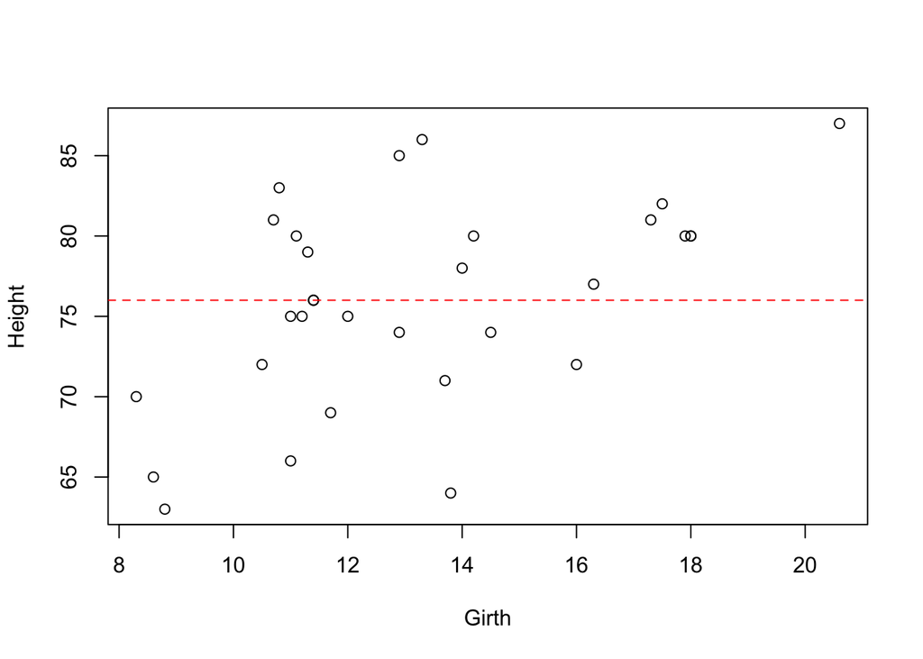

```r
# base R solution
plot(trees$Girth, trees$Height, xlab='Girth', ylab='Height')
abline(col='red',lty=2,h=mean(trees$Height))
```

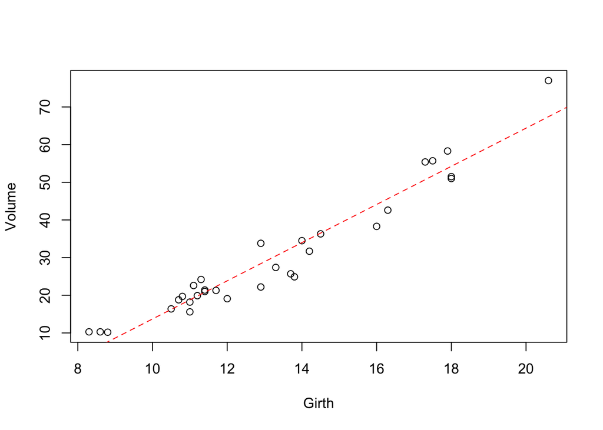

```r
plot(trees$Girth, trees$Volume, xlab='Girth', ylab='Volume')
fit <- lm(trees$Volume~trees$Girth)
abline(col='red',lty=2, coef(fit))
# ggplot solution
library(ggplot2)
```

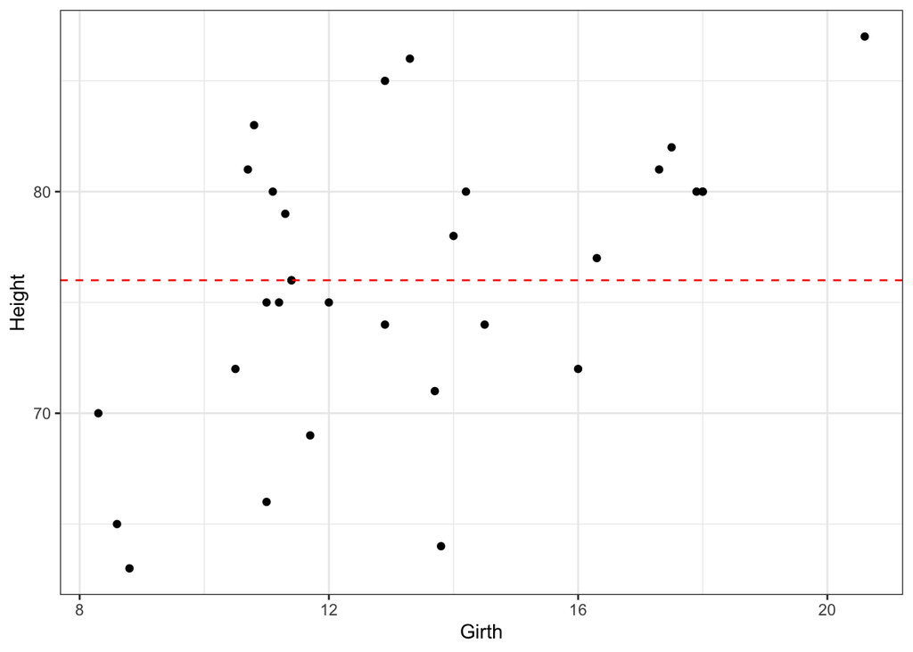

```r
library(tidyverse)
theme_set(theme_bw())
ggplot(data=trees, aes(Girth, Height))+
    geom_point()+geom_hline(col='red',yintercept=mean(trees$Height),lty=2)
```

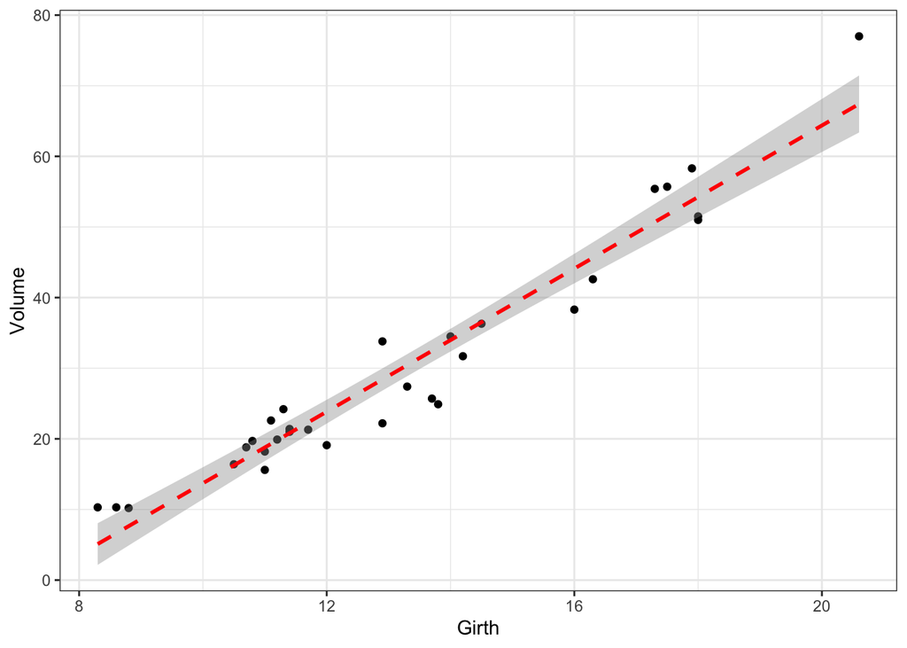

```r
ggplot(data=trees, aes(Girth, Volume))+
    geom_point()+geom_smooth(col='red',method="lm",lty=2)
```

- Explain your choice and write the corresponding values (average value and standard deviation, or slope, intercept and corresponding errors). Round the values to 2 decimals.

The average height is 76 with standard deviation 6.37.

The volume evolves with a slope 5.07 ± 0.25 and intercept -36.94 ± 3.37.

# 2 Exercise 2

- Print the 3 first lines of the R-built-in data.frame `USArrests`. This data set contains statistics about violent crime rates by US state. The numbers are given per 100 000 inhabitants, except for `UrbanPop` which is a percentage.

```r
head(USArrests,3)
```

```
##         Murder Assault UrbanPop Rape
## Alabama   13.2     236       58 21.2
## Alaska    10.0     263       48 44.5
## Arizona    8.1     294       80 31.0
```

- What is the average murder rate in the whole country?

```r
mean(USArrests$Murder)
```

```
## [1] 7.788
```

- What is the state with the highest assault rate?

```r
row.names(USArrests)[which.max(USArrests$Assault)]
```

```
## [1] "North Carolina"
```

- Create a subset of `USArrests` gathering the data for states with an urban population above (including) 80%.

```r
USArrests80 <- subset(USArrests, UrbanPop>=80)
# or
library(tidyverse)
USArrests80 <- USArrests %>% filter(UrbanPop>=80)
```

- How many states does that correspond to?

```r
nrow(USArrests80)
```

```
## [1] 12
```

- Within these states, what is the state with the smallest rape rate?

```r
row.names(USArrests80)[which.min(USArrests80$Rape)]
```

```
## [1] "Rhode Island"
```

- Print this subset ordered by decreasing urban population.

```r
USArrests80[order(-USArrests80$UrbanPop),]
```

```
##               Murder Assault UrbanPop Rape
## California       9.0     276       91 40.6
## New Jersey       7.4     159       89 18.8
## Rhode Island     3.4     174       87  8.3
## New York        11.1     254       86 26.1
## Massachusetts    4.4     149       85 16.3
## Hawaii           5.3      46       83 20.2
## Illinois        10.4     249       83 24.0
## Nevada          12.2     252       81 46.0
## Arizona          8.1     294       80 31.0
## Florida         15.4     335       80 31.9
## Texas           12.7     201       80 25.5
## Utah             3.2     120       80 22.9
```

- Print this subset ordered by decreasing urban population and increasing murder rate.

```r
USArrests80[order(-USArrests80$UrbanPop, USArrests80$Murder),]
```

```
##               Murder Assault UrbanPop Rape
## California       9.0     276       91 40.6
## New Jersey       7.4     159       89 18.8
## Rhode Island     3.4     174       87  8.3
## New York        11.1     254       86 26.1
## Massachusetts    4.4     149       85 16.3
## Hawaii           5.3      46       83 20.2
## Illinois        10.4     249       83 24.0
## Nevada          12.2     252       81 46.0
## Utah             3.2     120       80 22.9
## Arizona          8.1     294       80 31.0
## Texas           12.7     201       80 25.5
## Florida         15.4     335       80 31.9
```

- Plot an histogram of the percentage of urban population with a binning of 5%. Add a vertical red line marking the average value. Make sure the x axis shows the [0,100] range.

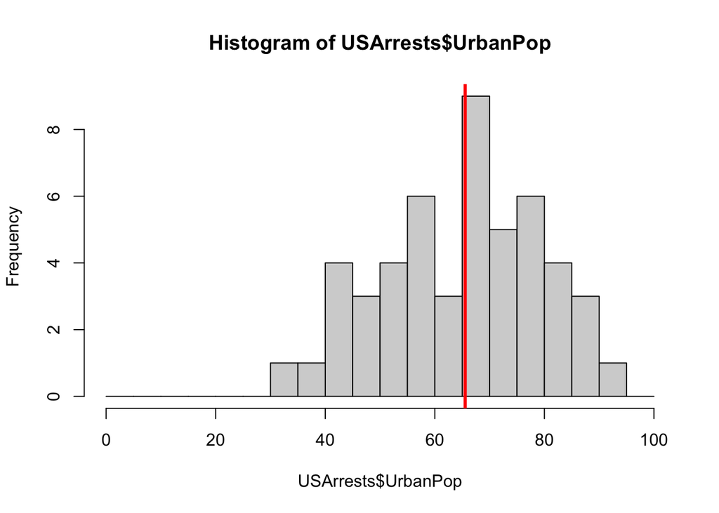

```r
hist(USArrests$UrbanPop, breaks=seq(0,100,5))
abline(v=mean(USArrests$UrbanPop), col='red', lwd=3)
```

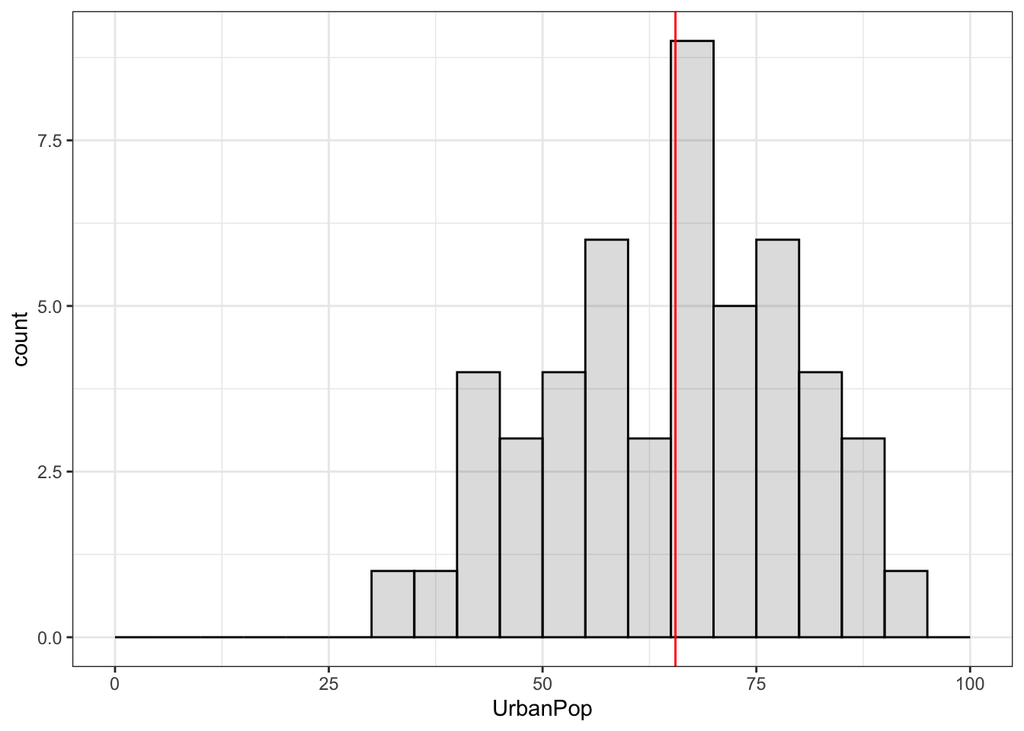

```r
# ggplot solution
library(ggplot2)
library(tidyverse)
theme_set(theme_bw())
ggplot(data=USArrests, aes(x=UrbanPop))+
    geom_histogram(breaks=seq(0,100,5),color="black", alpha=.2)+
    geom_vline(xintercept = mean(USArrests$UrbanPop), col='red')
```

- Is there a correlation between the percentage of urban population and the various violent crime rates? argument your answer with plots.

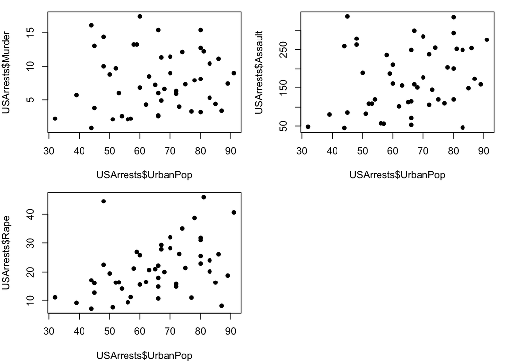

```r
par(mfrow=c(2,2),mar=c(4,4,1,1))
plot(USArrests$UrbanPop,USArrests$Murder, pch=16)
plot(USArrests$UrbanPop,USArrests$Assault, pch=16)
plot(USArrests$UrbanPop,USArrests$Rape, pch=16)
```

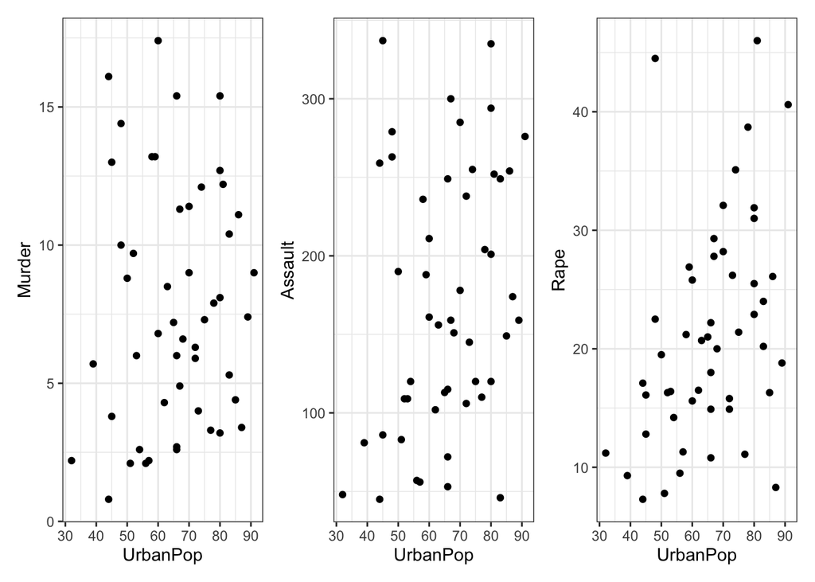

```r
library(ggplot2)
theme_set(theme_bw())
p1 <- ggplot(data=USArrests, aes(x=UrbanPop, y=Murder))+geom_point()
p2 <- ggplot(data=USArrests, aes(x=UrbanPop, y=Assault))+geom_point()
p3 <- ggplot(data=USArrests, aes(x=UrbanPop, y=Rape))+geom_point()
library(patchwork)
p1+p2+p3
```